# hw7

zyz

2020/12/12

## 1.读入数据并了解各个自变量的含义

```r
dat0 <- read.csv("simudata.csv")  #读入数据
summary(dat0) #对数据进行汇总
```

```
##      creded           debitF          meanpay           billnum
##  Min.   :0.0000   Min.   :  0.00   Min.   :      0   Min.   :  0.00
##  1st Qu.:0.0200   1st Qu.:  5.00   1st Qu.:  50475   1st Qu.: 11.00
##  Median :0.1000   Median : 25.00   Median : 231277   Median : 55.00
##  Mean   :0.1448   Mean   : 35.46   Mean   : 271800   Mean   : 74.47
##  3rd Qu.:0.2400   3rd Qu.: 57.00   3rd Qu.: 425342   3rd Qu.:119.00
##  Max.   :0.8200   Max.   :202.00   Max.   :1346594   Max.   :427.00
##      debitM          zhongxingM          sidaM            xindaiR
##  Min.   :     26   Min.   :      3   Min.   :     10   Min.   :  0.02
##  1st Qu.:  59310   1st Qu.:  21617   1st Qu.:  44692   1st Qu.: 70.17
##  Median : 264838   Median :  97913   Median : 219769   Median :155.52
##  Mean   : 305073   Mean   : 161771   Mean   : 271535   Mean   :163.34
##  3rd Qu.: 479646   3rd Qu.: 261094   3rd Qu.: 433841   3rd Qu.:241.02
##  Max.   :1436086   Max.   :1017770   Max.   :1299826   Max.   :365.00
##     cardnum          xindaiF          maxpay         zhuanzhangF
##  Min.   : 0.000   Min.   : 0.00   Min.   :      9   Min.   :  0.00
##  1st Qu.: 3.000   1st Qu.: 1.00   1st Qu.: 277166   1st Qu.:  3.00
##  Median : 6.000   Median : 4.00   Median :1182465   Median : 14.00
##  Mean   : 6.395   Mean   : 4.16   Mean   :1370679   Mean   : 22.19
##  3rd Qu.: 9.000   3rd Qu.: 7.00   3rd Qu.:2138145   3rd Qu.: 36.00
##  Max.   :26.000   Max.   :20.00   Max.   :6470316   Max.   :124.00
##    gongjiaoF       zhuanzhangR          age          gongjiaoR
##  Min.   :0.0000   Min.   :  0.28   Min.   :14.00   Min.   :206.3
##  1st Qu.:0.0000   1st Qu.:126.08   1st Qu.:27.00   1st Qu.:332.8
##  Median :0.0000   Median :219.46   Median :30.00   Median :359.5
##  Mean   :0.9369   Mean   :223.06   Mean   :29.98   Mean   :346.4
##  3rd Qu.:2.0000   3rd Qu.:308.47   3rd Qu.:33.00   3rd Qu.:365.0
##  Max.   :7.0000   Max.   :704.05   Max.   :47.00   Max.   :365.0
##      sidaF            sidaR          zhongxingF       zhongxingR
##  Min.   :  0.00   Min.   :  0.16   Min.   : 0.000   Min.   :  0.17
##  1st Qu.:  4.00   1st Qu.: 57.22   1st Qu.: 1.000   1st Qu.:157.15
##  Median : 17.00   Median :136.13   Median : 5.000   Median :251.33
##  Mean   : 25.26   Mean   :148.53   Mean   : 7.812   Mean   :237.54
##  3rd Qu.: 42.00   3rd Qu.:219.95   3rd Qu.:13.000   3rd Qu.:340.05
##  Max.   :144.00   Max.   :365.00   Max.   :53.000   Max.   :365.00
##     xiaofeiF          jinkaF        zhuanzhangM          gongjiaoM
##  Min.   : 0.000   Min.   : 0.000   Min.   :     38.2   Min.   :    0.02
##  1st Qu.: 0.000   1st Qu.: 1.000   1st Qu.:  45837.9   1st Qu.:  804.83
##  Median : 1.000   Median : 3.000   Median : 214517.8   Median : 2245.55
##  Mean   : 2.578   Mean   : 6.101   Mean   : 304697.9   Mean   : 6079.25
##  3rd Qu.: 4.000   3rd Qu.:10.000   3rd Qu.: 496300.3   3rd Qu.: 9483.37
##  Max.   :19.000   Max.   :44.000   Max.   :1650050.4   Max.   :55745.07
##      youxiM           xindaiS             black
##  Min.   :   0.00   Min.   :     8.1   Min.   :0.0000
##  1st Qu.:  28.05   1st Qu.: 18240.0   1st Qu.:0.0000
##  Median :  75.05   Median : 87971.4   Median :0.0000
##  Mean   : 209.64   Mean   :106103.7   Mean   :0.3337
##  3rd Qu.: 329.99   3rd Qu.:165942.2   3rd Qu.:1.0000
##  Max.   :1939.00   Max.   :485178.3   Max.   :1.0000
```

自变量的含义：  
· creded(借贷比率)：用户所有行为中，采用贷记卡（或称为信用卡）交易的次数占所有采用贷记卡或者借记卡（或称为储蓄卡）交易次数的比率；  
· debitF(借记类F)：用户使用储蓄卡的消费频率；  
· meanpay(所有行为均值)：用户被记录的所有交易行为的平均金额；  
· billnum(交易笔数)：用户自从第一笔交易记录开始，被记录的交易总笔数；  
· debitM(借记类M)：用户使用储蓄卡所有消费金额的平均值；  
· zhongxingM(中型银行M)：用户使用中型银行卡所有消费金额的平均值；  
· sidaM(四大行M)：用户使用四大行银行卡所有消费金额的平均值；  
· xindaiR(信贷类R)：用户上一次小额贷款的时间到现在的距离；  
· cardnum(银行卡数)：用户银行卡的数量；  
· xindaiF(信贷类F)：用户小型贷款的频率；  
· maxpay(所有行为最大值)：用户自从第一笔交易开始，所有交易行为的金额的最大值；  
· zhuanzhangF(转账类F)：用户转账的频率；  
· gongjiaoF(公缴类F)：用户交水，电，煤气费等交易行为的频率；  
· zhuanzhangR(转账类R)：用户最近一次转账的时间到现在的距离；  
· age(年龄)：用户的年龄；  
· gongjiaoR(公缴类R)：用户上一次交水，电，煤气费等交易的时间到现在的距离；  
· sidaF(四大行F)：用户使用四大行银行卡的频率;  
· sidaR(四大行R): 用户上一次使用四大行银行卡的时间到现在的距离;  
· zhongxingF(中型银行F)：用户使用中型银行卡的频率；  
· zhongxingR(中型银行R)：用户上一次使用中型银行卡的时间到现在的距离;  
· xiaofeiF(消费类F)：用户日常消费行为的频率；  
· jinkaF(金卡类F)：用户使用金卡消费的频率；  
· zhuanzhangM(转账类M)：用户转账金额的平均值；  
· gongjiaoM(公缴类M)：用户交水，电，煤气费等交易的平均金额；  
· youxiM(游戏类M)：用户购买游戏点卡的金额的平均值；  
· xindaiS(信贷类S)：用户的小额贷款的标准差；

## 2.按照7:3划分训练集和测试集，用多种机器学习模型进行建模；在测试集上进行测试，绘制ROC曲线，计算AUC值

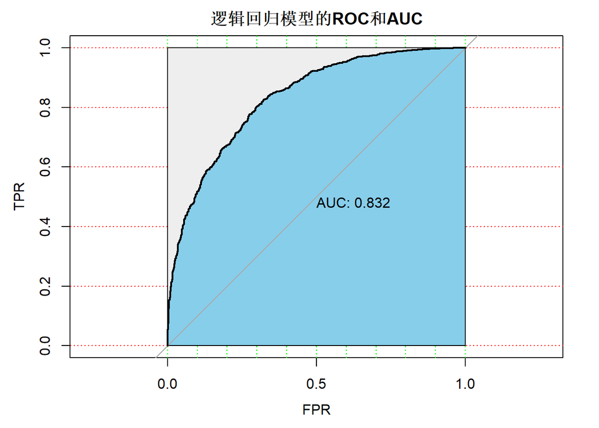

```r
library(pROC) #导入pROC包
set.seed(1234)
dat0[-27] <- scale(dat0[-27]) # 对所有自变量进行标准化
index <- sample(1:nrow(dat0), round(nrow(dat0)*7/10)) # 确定训练集数据下标
dat.train <- dat0[index,] #训练集
dat.test <- dat0[-index,] #测试集

# 逻辑回归模型
logis <- glm(formula = black ~ ., family = binomial(link = logit), data = dat.train)  #建立模型
logis_pred <- predict.glm(logis, type = "response", newdata = dat.test) # 进行预测
logis.roc <- roc(dat.test$black, logis_pred)
plot(logis.roc, print.auc=TRUE, auc.polygon=TRUE, legacy.axes=TRUE, grid=c(0.1, 0.2), grid.col=c("green", "red"), max.auc.polygon=TRUE,  auc.polygon.col="skyblue", main="逻辑回归模型的ROC和AUC", xlab = "FPR", ylab = "TPR")  #画出ROC并计算AUC

# kNN模型
library("kknn")
```

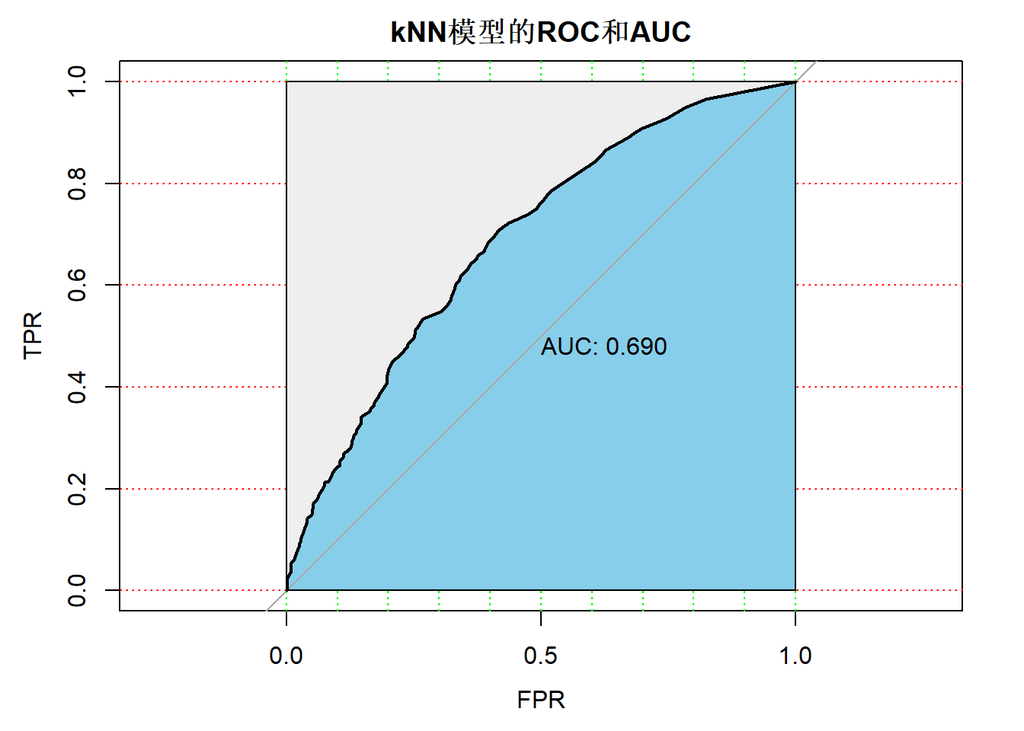

```r
knn <- kknn(formula = black ~ ., dat.train,dat.test, k=7, distance = 2) # 建立模型
knn_pred <- fitted(knn) #进行预测
knn.roc <- roc(dat.test$black, knn_pred)
plot(knn.roc, print.auc=TRUE, auc.polygon=TRUE, legacy.axes=TRUE, grid=c(0.1, 0.2), grid.col=c("green", "red"), max.auc.polygon=TRUE,  auc.polygon.col="skyblue", main="kNN模型的ROC和AUC", xlab = "FPR", ylab = "TPR")  #画出ROC并计算AUC
```

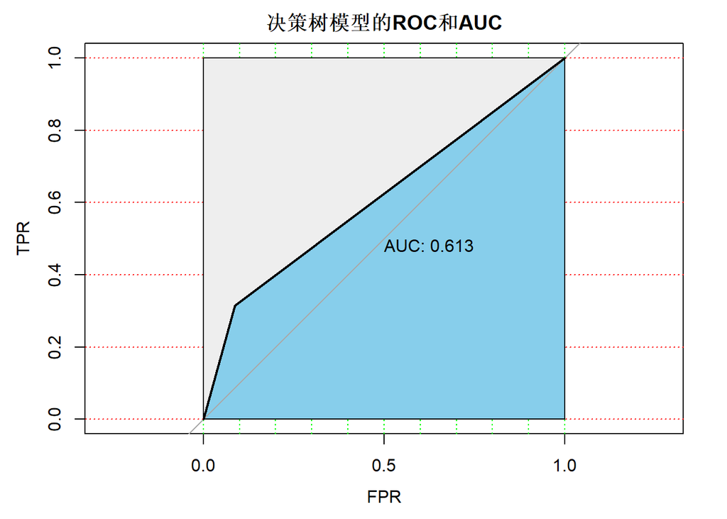

```r
# 决策树模型
library("rpart")
dtree <- rpart(black~., data = dat.train, method = "class") #建立模型
dtree_pred <- predict(dtree, newdata = dat.test, type = "class")  #进行预测
dtree_pred <- as.numeric(dtree_pred)-1
dtree.roc <- roc(dat.test$black, dtree_pred)
plot(dtree.roc, print.auc=TRUE, auc.polygon=TRUE, legacy.axes=TRUE, grid=c(0.1, 0.2), grid.col=c("green", "red"), max.auc.polygon=TRUE,  auc.polygon.col="skyblue", main="决策树模型的ROC和AUC", xlab = "FPR", ylab = "TPR")  #画出ROC并计算AUC
```

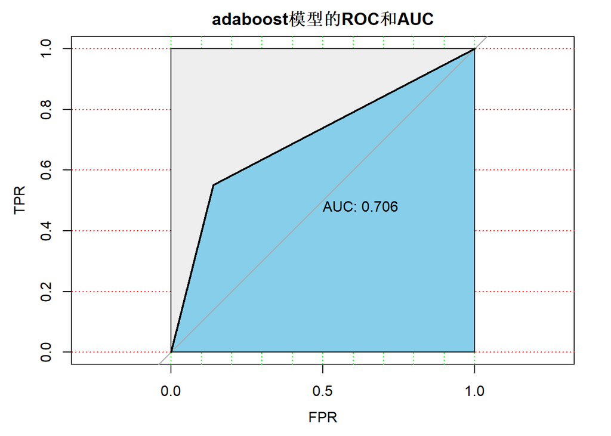

```r
# boosting模型
library("adabag")
dat.train$black <- as.factor(dat.train$black)
adabst <- boosting(black~., data = dat.train) #建立模型
adabst_pred <- predict(adabst, dat.test)  #进行预测
adabst_pred <- as.numeric(adabst_pred$class)
adabst.roc <- roc(dat.test$black, adabst_pred)
plot(adabst.roc, print.auc=TRUE, auc.polygon=TRUE, legacy.axes=TRUE, grid=c(0.1, 0.2), grid.col=c("green", "red"), max.auc.polygon=TRUE,  auc.polygon.col="skyblue", main="adaboost模型的ROC和AUC", xlab = "FPR", ylab = "TPR")  #画出ROC并计算AUC
```

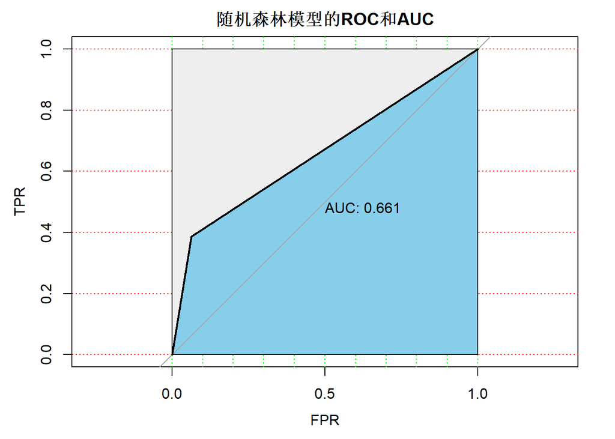

```r
# 随机森林模型
library(randomForest)
ranfor <- randomForest(black~., data = dat.train) #建立模型
ranfor_pred <- predict(ranfor, dat.test)  #进行预测
ranfor_pred <- as.numeric(ranfor_pred)-1
ranfor.roc <- roc(dat.test$black, ranfor_pred)
plot(ranfor.roc, print.auc=TRUE, auc.polygon=TRUE, legacy.axes=TRUE, grid=c(0.1, 0.2), grid.col=c("green", "red"), max.auc.polygon=TRUE,  auc.polygon.col="skyblue", main="随机森林模型的ROC和AUC", xlab = "FPR", ylab = "TPR")  #画出ROC并计算AUC
```

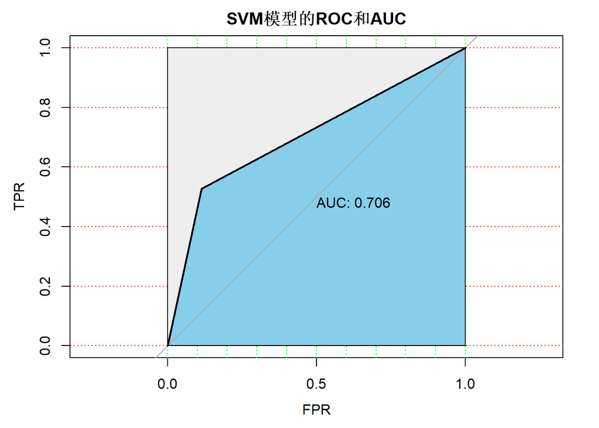

```r
# SVM模型
library(e1071)
svm1 <- svm(black~., data = dat.train, type="C", kernel="radial") #建立模型
svm_pred <- predict(svm1, dat.test) #进行预测
svm_pred <- as.numeric(svm_pred)-1
svm_roc <- roc(dat.test$black, svm_pred)
plot(svm_roc, print.auc=TRUE, auc.polygon=TRUE, legacy.axes=TRUE, grid=c(0.1, 0.2), grid.col=c("green", "red"), max.auc.polygon=TRUE,  auc.polygon.col="skyblue", main="SVM模型的ROC和AUC", xlab = "FPR", ylab = "TPR")  #画出ROC并计算AUC
```

## 3.对比以上模型的AUC值和ROC曲线，选择一个最优的模型，并说明理由。

由以上得到的结果可以看到，逻辑回归得到的AUC是最高的，明显高于其他模型，但这其中可能有其他模型参数选择的问题，但逻辑回归模型的效果是非常不错的，因此选择逻辑回归模型。